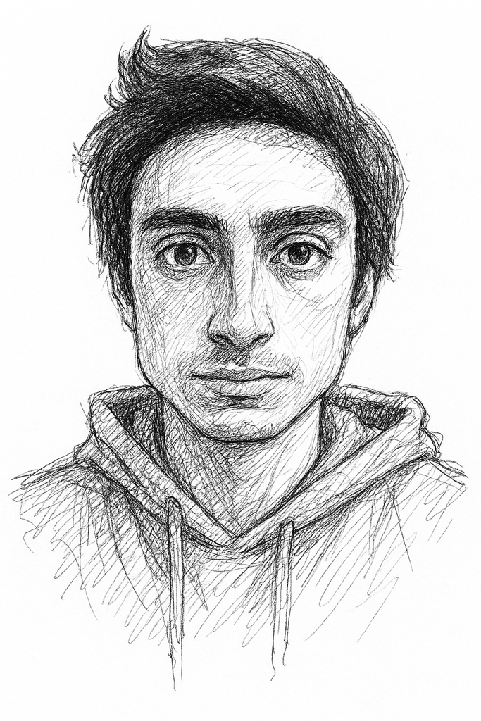

# wenceslao arroyo machado

## personal links*

you can find my full academic profile on [orcid](https://orcid.org/), browse all my publications on [google scholar](https://scholar.google.com/), and follow updates on both [twitter](https://twitter.com/) and [bluesky](https://bsky.app/). i also share code on [github](https://github.com/), post materials on [hackmd](https://hackmd.io/), and occasionally write informal thoughts on [influscience](https://www.influscience.eu/).

**i’m present on other platforms too, but i don’t keep them as active or up to date as these*

## short bio

i am currently a postdoctoral researcher at ingenio (csic-upv) under a momentum contract. my academic background is rooted in scientometrics and data analysis, with a strong foundation developed during my predoctoral training in granada (spain). i have published extensively in leading scientometrics journals and regularly serve as a peer reviewer. in addition to my research activity, i have been actively involved in various national and international research and educational projects. in 2024, i held a postdoctoral position at arizona state university, further expanding my international research experience. in the same year, i was awarded a juan de la cierva contract, which i declined in order to accept the momentum fellowship. my professional profile also includes significant contributions to knowledge transfer as the chief operating officer of the [ec3metrics spin-off](https://yosigo.ugr.es). i have organized and taught courses both nationally and internationally, contributing to initiatives such as the european summer school for scientometrics and [#yosigougr](https://yosigo.ugr.es).

## research focus & key contributions

• **big data & large-scale informetric analysis**  
my main contribution has been processing and generating an open [knowledge graph of wikipedia](https://doi.org/10.1162/qss_a_00226)

• **altmetrics & mapping social media**  
i’ve [mapped engagement](https://doi.org/10.1007/s11192-021-04167-8) around science on twitter

• **new methods in science communication**  
i developed a proposal to identify and quantify the impact of twitter bots on scientific discussions

• **research evaluation**  
i’ve contributed to the development of [narrative bibliometrics](https://doi.org/10.1016/j.joi.2024.101546)

• **applications of generative ai in academia**  
i’ve helped integrate ai into academia through [manuals and guides](https://doi.org/10.5281/zenodo.10025783)